# Using ARIMA Models For Forecasting Electricity Power Demand

## In this notebook we will:

- Show and introduce our data.
- Clean Data.
- Analyze data to figure its structure like stationary, seasonality, autocorrelation, partial autocorrelation.
- Build ML Model to predict future Electricity Power Demand.

#### Load our data

| Time | Demand | Temperature | Holiday |
| --- | --- | --- | --- |
| 2012-01-01 | 3751.442996 | 21.047727 | 1.0 |
| 2012-01-02 | 4745.380361 | 26.578125 | 1.0 |
| 2012-01-03 | 5739.395602 | 31.751042 | 1.0 |
| 2012-01-04 | 5394.902696 | 24.567708 | 0.0 |
| 2012-01-05 | 4454.007853 | 18.191667 | 0.0 |

#### Data Information and Number of rows and columns

```
<class 'pandas.core.frame.DataFrame'>
DatetimeIndex: 1097 entries, 2012-01-01 to 2015-01-01
Freq: D
Data columns (total 3 columns):
 #   Column       Non-Null Count  Dtype
---  ------       --------------  -----
 0   Demand       1097 non-null   float64
 1   Temperature  1097 non-null   float64
 2   Holiday      1097 non-null   float64
dtypes: float64(3)
memory usage: 34.3 KB
```

#### check null values

```
Demand         0
Temperature    0
Holiday        0
dtype: int64
```

##### Summary Statistics

|  | Demand | Temperature | Holiday |
| --- | --- | --- | --- |
| count | 1097.000000 | 1097.000000 | 1097.000000 |
| mean | 4664.718977 | 16.269425 | 0.052871 |
| std | 518.129963 | 4.901892 | 0.223879 |
| min | 3340.564754 | 6.570833 | 0.000000 |
| 25% | 4320.722537 | 12.537500 | 0.000000 |
| 50% | 4657.565292 | 15.700000 | 0.000000 |
| 75% | 4981.148367 | 19.161458 | 0.000000 |
| max | 7322.074134 | 36.314583 | 1.000000 |

## Pre-modeling analysis

#### Check Seasonality

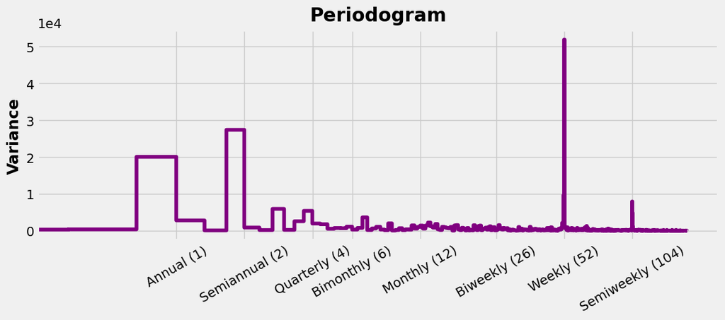

*Strong Seasonality Annual and Weekly*

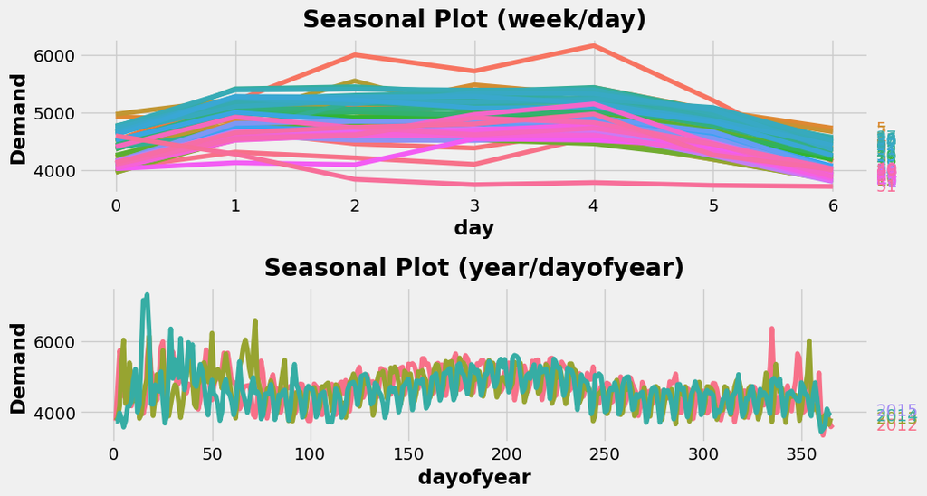

*- It is observed that there is a lower demand values during the weekend.*

*- It is observed that there is an annual seasonality, with higher demand values in June, July, and August, and with high demand peaks in November, December, January, February, and March.*

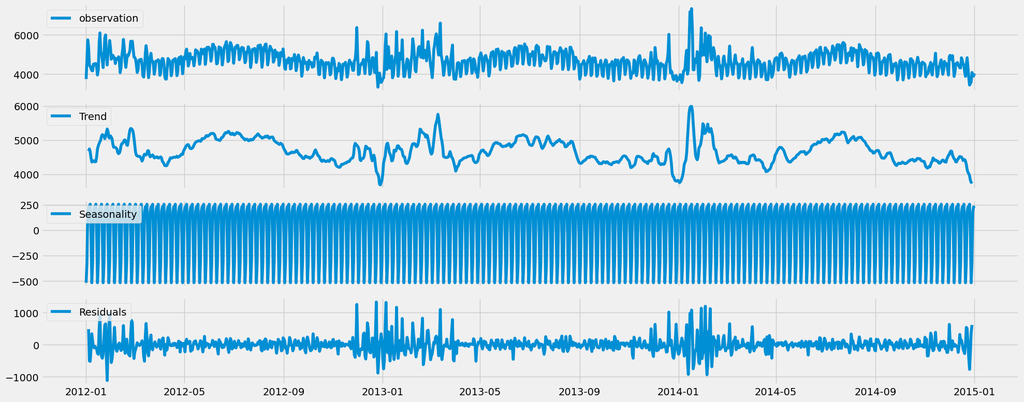

- *There is no trend in our data.*
- *There is volatility in the beginning of every year.*

### Data splitting

```
All Data Rows Is: 1097, Data Train Rows Is: 1067, Data Test Rows Is: 30
```

- ARIMA model has 3 core hyper-parameters, known as 'order'.
- p: The order of the auto-regressive (AR) model (i.e., the number of lag observations)
- d: The degree of differencing.
- q: The order of the moving average (MA) model. This is essentially the size of the 'window' function over your time series data

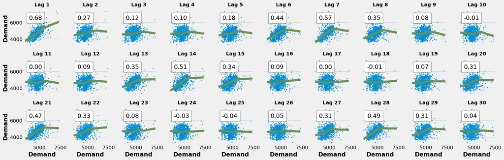

```
(-0.5, 1.0)
```

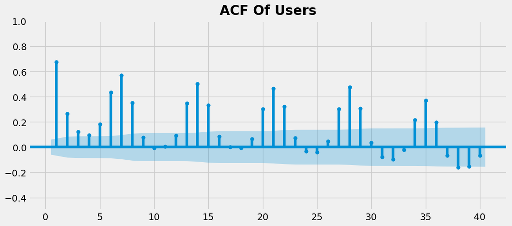

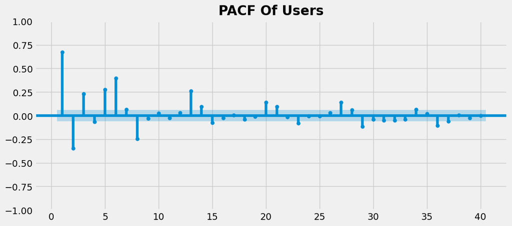

*The autocorrelation and partial autocorrelation plots show a clear association between one day's demand and previous days, as well as between one day's demand and the same day's demand on previous days. This type of correlation is an indication that autoregressive models can work well.*

#### Check data stationary

```
adfuller Pvalue = 0.0
lags = 22
Our Data Is Stationary according to ADFuller Test

normaltest Pvalue = 0.0
Our Data Is Nonstationary according to Normal Test
```

### Estimating the differencing term.

```
Pvalue Is: 0.01
Should we difference at the alpha=0.05? True
Number of differences using kpss test Is: 1
Number of differences using adf test Is: 0
```

# Fitting our model

```
Performing stepwise search to minimize aic
 ARIMA(2,1,2)(1,0,1)[7] intercept   : AIC=inf, Time=2.36 sec
 ARIMA(0,1,0)(0,0,0)[7] intercept   : AIC=15757.150, Time=0.14 sec
 ARIMA(1,1,0)(1,0,0)[7] intercept   : AIC=15231.478, Time=1.61 sec
 ARIMA(0,1,1)(0,0,1)[7] intercept   : AIC=15452.413, Time=1.58 sec
 ARIMA(0,1,0)(0,0,0)[7]             : AIC=15755.156, Time=0.41 sec
 ARIMA(1,1,0)(0,0,0)[7] intercept   : AIC=15740.322, Time=0.42 sec
 ARIMA(1,1,0)(2,0,0)[7] intercept   : AIC=15109.999, Time=1.78 sec
 ARIMA(1,1,0)(2,0,1)[7] intercept   : AIC=inf, Time=2.91 sec
 ARIMA(1,1,0)(1,0,1)[7] intercept   : AIC=inf, Time=2.17 sec
 ARIMA(0,1,0)(2,0,0)[7] intercept   : AIC=15098.501, Time=2.47 sec
 ARIMA(0,1,0)(1,0,0)[7] intercept   : AIC=15228.985, Time=1.29 sec
 ARIMA(0,1,0)(2,0,1)[7] intercept   : AIC=inf, Time=3.65 sec
 ARIMA(0,1,0)(1,0,1)[7] intercept   : AIC=inf, Time=2.11 sec
 ARIMA(0,1,1)(2,0,0)[7] intercept   : AIC=15104.703, Time=2.94 sec
 ARIMA(1,1,1)(2,0,0)[7] intercept   : AIC=inf, Time=3.26 sec
 ARIMA(0,1,0)(2,0,0)[7]             : AIC=15096.024, Time=2.16 sec
 ARIMA(0,1,0)(1,0,0)[7]             : AIC=15226.991, Time=0.94 sec
 ARIMA(0,1,0)(2,0,1)[7]             : AIC=inf, Time=2.48 sec
 ARIMA(0,1,0)(1,0,1)[7]             : AIC=inf, Time=1.07 sec
 ARIMA(1,1,0)(2,0,0)[7]             : AIC=15107.998, Time=1.80 sec
 ARIMA(0,1,1)(2,0,0)[7]             : AIC=15098.231, Time=2.77 sec
 ARIMA(1,1,1)(2,0,0)[7]             : AIC=inf, Time=3.10 sec

Best model:  ARIMA(0,1,0)(2,0,0)[7]
Total fit time: 43.447 seconds
```

SARIMAX Results

| Dep. Variable: | y | No. Observations: | 1067 |
| --- | --- | --- | --- |
| Model: | SARIMAX(0, 1, 0)x(2, 0, 0, 7) | Log Likelihood | -7543.012 |
| Date: | Wed, 19 Apr 2023 | AIC | 15096.024 |
| Time: | 07:50:15 | BIC | 15120.882 |
| Sample: | 0 | HQIC | 15105.443 |
|  | - 1067 |  |  |
| Covariance Type: | opg |  |  |

|  | coef | std err | z | P>\|z\| | [0.025 | 0.975] |
| --- | --- | --- | --- | --- | --- | --- |
| x1 | 40.1099 | 1.697 | 23.640 | 0.000 | 36.784 | 43.435 |
| x2 | -374.7218 | 37.483 | -9.997 | 0.000 | -448.188 | -301.256 |
| ar.S.L7 | 0.4123 | 0.024 | 16.970 | 0.000 | 0.365 | 0.460 |
| ar.S.L14 | 0.3460 | 0.026 | 13.404 | 0.000 | 0.295 | 0.397 |
| sigma2 | 8.389e+04 | 3130.064 | 26.801 | 0.000 | 7.78e+04 | 9e+04 |

| Ljung-Box (L1) (Q): | 0.16 | Jarque-Bera (JB): | 216.23 |
| --- | --- | --- | --- |
| Prob(Q): | 0.68 | Prob(JB): | 0.00 |
| Heteroskedasticity (H): | 1.25 | Skew: | -0.23 |
| Prob(H) (two-sided): | 0.03 | Kurtosis: | 5.16 |

Warnings:  
[1] Covariance matrix calculated using the outer product of gradients (complex-step).

#### Get prediction for Train Data.

```
Mean Absolute Error For Train Data Is: 218.42025589514367
Summetric Mean Absolute Error Percentage For Train Data Is: 4.734806235858657
```

#### Viewing Prediction for Train Data.

[figure not shown]

#### Updating the model and get prediction for Test Data.

```
Mean Absolute Error For Test Data Is: 121.9589701958039
Summetric Mean Absolute Error Percentage For Test Data Is: 2.942540615100554
```

#### Viewing forecasts for Test Data.

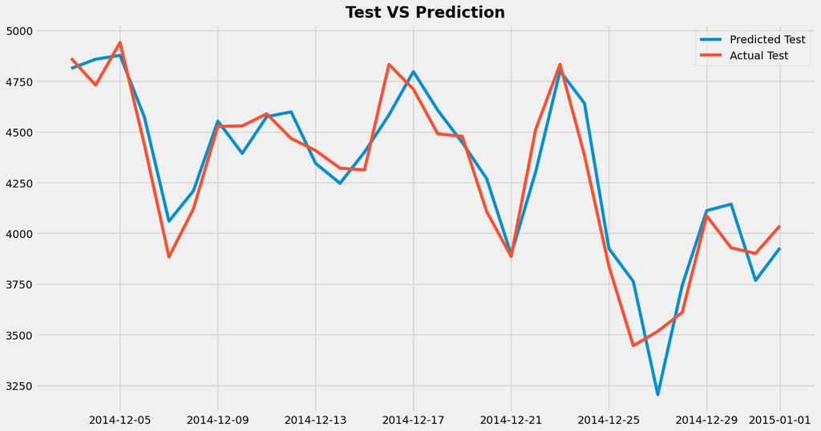

# Model diagnosis.

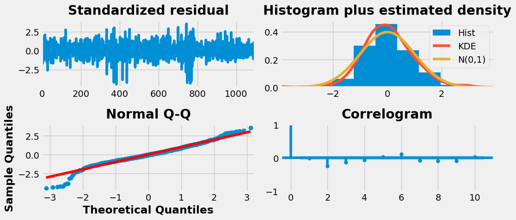

[figure not shown]